# Introduction

Cancer is a problem that affects people of all nationalities. The problem is so common that most people at this point either know someone personally, or they themselves have been affected directly by cancer. Furthermore, the process for correctly identifying cancers takes time, as well as a trained professional who may make a misdiagnosis, or may not be available in time to help the individual. This all directly affects the quality of the individual's life and life expectancy. As the earlier that a malignant tumour is identified the sooner that treatment can be started and the better the expected outcome of the illness. This is an area that machine learning is specifically suited to help.

# Methodology

It has been observed over time that there are hidden patterns between patients affected by the same types of cancers. It has also been observed that deep learning networks excel at modelling patterns that are not readily apparent. Therefore the aim of this project is to correctly identify images of Breast Lesions as one of the following:

- malignant
- benign
- normal

This will be done through utilising "Breast Ultrasound Images Dataset" a public licenced dataset hosted by kaggle.

- https://www.kaggle.com/datasets/aryashah2k/breast-ultrasound-images-dataset [1].

The image dataset will be used in conjunction with Python, Tensorflow and Keras. This will be in order to train a deep learning network that will be able accurately model the patterns in the cancer images. The project follows a deductive method to explore the design and construction of deep learning networks, starting with a model that beats a common sense baseline.

### Dataset Description

- Dataset hosted by kaggle: https://www.kaggle.com/datasets/aryashah2k/breast-ultrasound-images-dataset
- The data collected at baseline include breast ultrasound images among women in ages between 25 and 75 years old. This data was collected in 2018. The number of patients is 600 female patients. The dataset consists of 780 images with an average image size of 500*500 pixels. The images are in PNG format. The ground truth images are presented with original images. The images are categorised into three classes, which are normal, benign, and malignant. [1]

The following Python packages will be extensively used to model and display the images

### Python Modules

```python
# system
import os
import pathlib

# Mathematical Computation
import numpy as np

# Machine Learning Library
import tensorflow as tf

# plotting
import matplotlib.pyplot as plt
import seaborn as sns
```

The following helper functions were used to process the data into a usable format for Tensorflow, graph learning model output and to decode the images for easy display.

### Helper Functions

```python
#             Image Processing
#----------------------------------------------#

# decode image
def decode_image(file_path):
    img = tf.io.read_file(file_path)
    img = tf.image.decode_png(img)

    # normalize the image
    img = tf.cast(img, tf.float32) / 255.0
    img = tf.image.resize(img, (224,224))

    # convert image from grayscale to rgb (some images are grayscale and others are RGB)
    if tf.shape(img)[2] == tf.convert_to_tensor(1):
        img = tf.image.grayscale_to_rgb(img)
    return img

# ouputting the image and class label
def convert_ds(file_path):
    img = decode_image(file_path)
    label = tf.strings.split(file_path, os.path.sep)[-2] == classes
    return img, tf.argmax(label)

#            Image Display
#----------------------------------------------#
#draws a grid on the image display
sns.set(style="whitegrid")

# Displays a single image with class label
def show_single(img, label):
    plt.imshow(img)
    plt.title(label)

# Displays a grid of sample images with attached class labels
def show_batch(img_batch, label_batch):
    figure = plt.figure(figsize=(12, 10))
    n = 16
    sqrt = int(np.sqrt(n))
    for i in range(n):
        _ = plt.subplot(sqrt, sqrt, i + 1)
        show_single(img_batch[i], classes[label_batch[i]])
        plt.axis('off')
    plt.show()

#             Dataset Orginisation
#----------------------------------------------#
def configure_for_training(data, is_train=False):
    data = data.cache()
    data = data.shuffle(buffer_size=300)
    data = data.batch(32)
    # if is_train:
        # do some augmentations
    data = data.prefetch(buffer_size=tf.data.AUTOTUNE)
    return data

#             Callback functions
#----------------------------------------------#
#Displays a spinning icon while the model runs
class CustomCallback(tf.keras.callbacks.Callback):
    def on_epoch_begin(self, epoch, logs=None):
        c = ['\b|', '\b/', '\b-', '\b\\']
        print(c[epoch % 4], end='')
    def on_epoch_end(self, epoch, logs=None):
        print('\b', end='')

# #stops the training when the model stops changing
# earlystoper = tf.keras.callbacks.EarlyStopping(
#                                             monitor='val_loss',
#                                             patience=10,
#                                             verbose=0,
#                                             mode='auto',
#                                             ## This will ensure the best instance of the model over the validation set.
#                                             restore_best_weights=True)

# #store the best model for reuse
# mc = tf.keras.callbacks.ModelCheckpoint(
#                                     'best_model.h5',
#                                     monitor='val_loss',
#                                     mode='min',
#                                     verbose=0)

#           Ploting the Model Output
#----------------------------------------------#
# visualize the training and validation accuracies and losses
def visualize_loss(history):
    train_loss = history["loss"]
    val_loss = history["val_loss"]

    iterations = [i for i in range(EPOCHS)]

    plt.plot(iterations, train_loss, label="Training Loss", color="b")
    plt.plot(iterations, val_loss, label="Validation Loss", color="r")
    plt.title("Training and Validation Loss")
    plt.legend()
    plt.show()

def visualize_acc(history):
    train_loss = history["acc"]
    val_loss = history["val_acc"]

    iterations = [i for i in range(EPOCHS)]


    plt.plot(iterations, train_loss, label="Training Accuracy", color="b")
    plt.plot(iterations, val_loss, label="Validation Accuracy", color="r")
    plt.title("Training and Validation accuracy")
    plt.legend()
    plt.show()
```

### Loading the Dataset

```python
# because the class labels are the folder names we will need to call this more then once
data_dir = ".\Dataset_BUSI_with_GT"

# get the image data set from the local storage
# get real image only, the mask has name _mask.png
image_ds = tf.data.Dataset.list_files(str(pathlib.Path(data_dir) /"*/*).png"), shuffle='False')
```

### Exploring the Image Dataset

Examining the number of available samples in the data set.

```python
ds_size = len(image_ds)

print('There are', ds_size,'images in this dataset')
```

```
There are 780 images in this dataset
```

From the previous cell we can see that there are a total of 780 images in this dataset. Because of the relatively small number of images, this implies using k-fold cross validation as the optimal choice for training our deep learning model. However, for testing purposes and our baseline model, we will initially use hold out validation (training set and testing set).

Viewing a small selection of the loaded image file paths from the dataset and the dataset class labels. To better understand the current structure of the data.

```python
#view the files and image class
for i in image_ds.take(1):
    print(i.numpy())

    # getting the image class from the filepath\
    split = tf.strings.split(i, os.path.sep)
    print("\n","This image belongs to the", split[-2].numpy(),"Class\n")

#view the file directories
classes = os.listdir(data_dir)
num_classes= len(classes)
print('\n',"There are",num_classes,"Available Class Labels =", classes,'\n')
```

```
b'Dataset_BUSI_with_GT\\malignant\\malignant (82).png'

 This image belongs to the b'malignant' Class


 There are 3 Available Class Labels = ['benign', 'malignant', 'normal']
```

As there are 3 possible classifications, but the possibility of only belonging to one label. We can see that this will be a multiclass single-label classification problem. Therefore when building the model our last layer's activation will be a "softmax" activation with a loss function of "categorical cross entropy".

Currently the dataset is a series of png images of approximate size of 550 *450 pixels. This file size is quite large and needs to be converted to the smaller scale of 224* 224 pixels. Furthermore, the png format needs to be converted to a tensor in order to work with tensorflow. Two helper functions were created to work together using list comprehension, to resize the images, convert them to a tensor, and attach the class label as an int, finally returning the converted data set. As loading images and converting them can be computationally expensive, the keras api provides the functional ability to monitor and tune data calls in the background for peak efficiency.

```python
data = image_ds.map(convert_ds, num_parallel_calls=tf.data.AUTOTUNE)
```

Viewing a sample of the newly converted dataset to better visualise the new format.

```python
for img, label in data.take(1):
    print("The attached label is =>",label.numpy(),"This image is from the",classes[label.numpy()],"class\n")
    print(img)
```

```
The attached label is => 2 This image is from the normal class

tf.Tensor(
[[[0.2888918  0.2888918  0.2888918 ]
  [0.06514096 0.06514096 0.06514096]
  [0.3996197  0.3996197  0.3996197 ]
  ...
  [0.86327416 0.86327416 0.86327416]
  [0.8726103  0.8726103  0.8726103 ]
  [0.84467876 0.84467876 0.84467876]]

 [[0.30168355 0.30168355 0.30168355]
  [0.07729559 0.07729559 0.07729559]
  [0.30246583 0.30246583 0.30246583]
  ...
  [0.8597977  0.8597977  0.8597977 ]
  [0.8652569  0.8652569  0.8652569 ]
  [0.8329189  0.8329189  0.8329189 ]]

 [[0.2954657  0.2954657  0.2954657 ]
  [0.06067653 0.06067653 0.06067653]
  [0.793643   0.793643   0.793643  ]
  ...
  [0.8286483  0.8286483  0.8286483 ]
  [0.7722137  0.7722137  0.7722137 ]
  [0.784523   0.784523   0.784523  ]]

 ...

 [[0.2366286  0.2366286  0.2366286 ]
  [0.25327697 0.25327697 0.25327697]
  [0.21538633 0.21538633 0.21538633]
  ...
  [0.16849862 0.16849862 0.16849862]
  [0.16333693 0.16333693 0.16333693]
  [0.17604168 0.17604168 0.17604168]]

 [[0.17674482 0.17674482 0.17674482]
  [0.19107157 0.19107157 0.19107157]
  [0.18498775 0.18498775 0.18498775]
  ...
  [0.11307468 0.11307468 0.11307468]
  [0.11101221 0.11101221 0.11101221]
  [0.11561339 0.11561339 0.11561339]]

 [[0.1677171  0.1677171  0.1677171 ]
  [0.1477795  0.1477795  0.1477795 ]
  [0.1640271  0.1640271  0.1640271 ]
  ...
  [0.13409887 0.13409887 0.13409887]
  [0.12913492 0.12913492 0.12913492]
  [0.13092616 0.13092616 0.13092616]]], shape=(224, 224, 3), dtype=float32)
```

At this stage the data is in the correct format. However, the data still needs to be split into the test, train, and validation set that will be used initially to build a baseline learning model. The baseline learning model needs to only beat 33% accuracy or the accuracy of randomly assigning an image to one of the 3 class labels.

```python
# we split the dataset
test_size = int(ds_size * 0.2)
train_data = data.skip(test_size)
test_data = data.take(test_size)
print('Size of the training dataset:', len(train_data))
print('Size of the testing dataset:',len(test_data))
```

```
Size of the training dataset: 624
Size of the testing dataset: 156
```

```python
train_data = configure_for_training(train_data, is_train=True)
test_data = configure_for_training(test_data, is_train=True)
```

Displaying a sample of images from the processed dataset to examine if the data has been represented well.

```
The Image Batch Shape -> (32, 224, 224, 3)

The Label Batch Shape -> (32,)
```

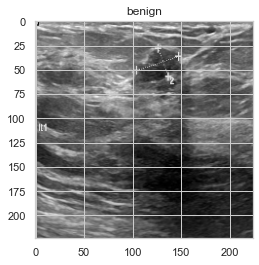

```python
for image_batch, label_batch in train_data.take(1):
    print("The Image Batch Shape ->",image_batch.shape,"\n")
    print("The Label Batch Shape ->",label_batch.shape)
show_single(image_batch.numpy()[0], classes[label_batch.numpy()[0]])
```

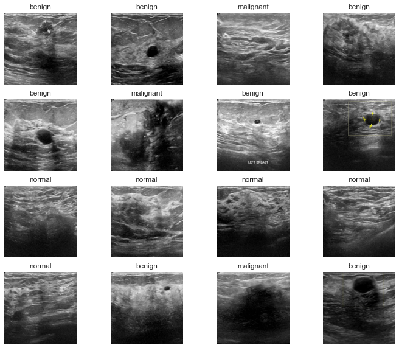

```python
show_batch(image_batch, label_batch)
```

### Baseline Model and Building the Network

In building the baseline model we will start with a simple hold out validation setup of the dataset (train data, test data) in order to test the simplest system for accuracy of prediction. As was stated before this model only needs to perform with an accuracy greater than 33%, or the accuracy of a model randomly guessing one of the 3 class labels.

```python
#             Building the Model
#----------------------------------------------#
def base_model():
    inputs = tf.keras.layers.Input(shape=(224,224,3))

    x = tf.keras.layers.Conv2D(filters=32,
                          kernel_size=(3,3),
                          strides=(1,1),
                          padding='valid',
                          activation='relu')(inputs)

    x = tf.keras.layers.MaxPooling2D(pool_size=(2,2))(x)
    x = tf.keras.layers.GlobalAveragePooling2D()(x)

    #x = tf.keras.layers.Flatten()(x)

    outputs = tf.keras.layers.Dense(num_classes, activation='softmax')(x)

    return tf.keras.models.Model(inputs=inputs, outputs=outputs)
```

```python
base_model = base_model()
base_model.compile(optimizer='adam',
                   loss='sparse_categorical_crossentropy',
                   metrics=['acc'])
base_model.summary()
```

```
Model: "model"
_________________________________________________________________
 Layer (type)                Output Shape              Param #
=================================================================
 input_1 (InputLayer)        [(None, 224, 224, 3)]     0

 conv2d (Conv2D)             (None, 222, 222, 32)      896

 max_pooling2d (MaxPooling2D  (None, 111, 111, 32)     0
 )

 global_average_pooling2d (G  (None, 32)               0
 lobalAveragePooling2D)

 dense (Dense)               (None, 3)                 99

=================================================================
Total params: 995
Trainable params: 995
Non-trainable params: 0
_________________________________________________________________
```

From the model summary we can see the model has a total of 995 trainable parameters for learning the patterns of the data set.

```python
EPOCHS = 2
BATCH_SIZE = 32
```

```python
history = base_model.fit(
                    train_data,
                    validation_data=test_data,
                    epochs=EPOCHS,
                    batch_size=BATCH_SIZE,
                    verbose=0,
                    callbacks=[CustomCallback()])
```

```python
_, train_acc = base_model.evaluate(train_data, verbose=0)
_, test_acc = base_model.evaluate(test_data, verbose=0)
print('Training accuracy: %.3f, Testing accuracy: %.3f' % (train_acc, test_acc))
```

```
Training accuracy: 0.545, Testing accuracy: 0.571
```

We can see from the previous cell when evaluating the baseline model, it produced a test accuracy that is significantly better than the common sense baseline of approxiamly 33%.

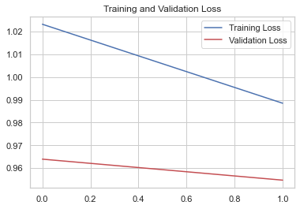

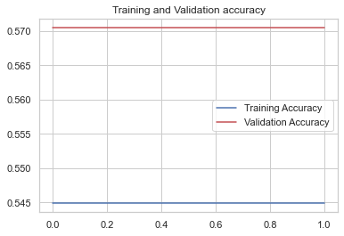

```python
visualize_loss(history.history)
visualize_acc(history.history)
```

However, from inspecting the graphed training and validation key features:

- Loss
- Accuracy

It has been shown that the model had not yet converged on its optimal number of epochs for training. Or rather the point where the validation loss and training loss converge before overfitting. To find the point of convergence the number of training epochs will be increased to 600.

### Training for More Epochs

```python
EPOCHS = 600
```

```python
history = base_model.fit(
                    train_data,
                    validation_data=test_data,
                    epochs=EPOCHS,
                    batch_size=BATCH_SIZE,
                    verbose=0,
                    callbacks=[CustomCallback()])
```

```python
_, train_acc = base_model.evaluate(train_data, verbose=0)
_, test_acc = base_model.evaluate(test_data, verbose=0)
print('Training accuracy: %.3f, Testing accuracy: %.3f' % (train_acc, test_acc))
```

```
Training accuracy: 0.590, Testing accuracy: 0.609
```

We can see from the testing accuracy that even though the number of training epochs was significantly increased, there wasn't a significant increase in accuracy. This suggests that the model is either currently too small or needs a longer period of training. To better understand the progress of the model we will output the graph of the training and validation loss and accuracy.

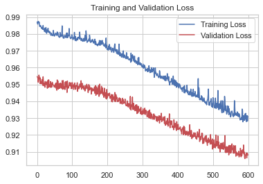

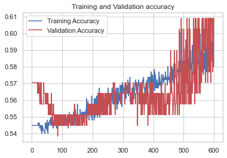

```
The lowest Validation Loss occured in the 591 epoch
```

```python
visualize_loss(history.history)
visualize_acc(history.history)
BEST_EPOCH = np.argmin(history.history['val_loss'])
print('The lowest Validation Loss occured in the', BEST_EPOCH, 'epoch')
```

From the graphed output we can see the model appears to be headed to convergence slowly. It can also be seen that there is a lot of noise in the training model. To increase the speed of convergence and deal with the noise a second convolution layer will be added and the global average pooling layer will be replaced with a flatten layer.

### Building a Bigger Model

```python
def model():
    inputs = tf.keras.layers.Input(shape=(224,224,3))

    x = tf.keras.layers.Conv2D(filters=32,
                          kernel_size=(3,3),
                          strides=(1,1),
                          padding='valid',
                          activation='relu')(inputs)

    x = tf.keras.layers.Conv2D(filters=32,
                          kernel_size=(3,3),
                          strides=(1,1),
                          padding='valid',
                          activation='relu')(x)

    x = tf.keras.layers.MaxPooling2D(pool_size=(2,2))(x)
#     x = tf.keras.layers.GlobalAveragePooling2D()(x)

#     x = tf.keras.layers.Dense(128, activation='relu')(x)
#     x = tf.keras.layers.Dense(32, activation='relu')(x)

    x = tf.keras.layers.Flatten()(x)

    outputs = tf.keras.layers.Dense(num_classes, activation='softmax')(x)

    return tf.keras.models.Model(inputs=inputs, outputs=outputs)
```

```python
model = model()
model.compile(optimizer='adam',
              loss='sparse_categorical_crossentropy',
              metrics=['acc'])
model.summary()
```

```
Model: "model_1"
_________________________________________________________________
 Layer (type)                Output Shape              Param #
=================================================================
 input_2 (InputLayer)        [(None, 224, 224, 3)]     0

 conv2d_1 (Conv2D)           (None, 222, 222, 32)      896

 conv2d_2 (Conv2D)           (None, 220, 220, 32)      9248

 max_pooling2d_1 (MaxPooling  (None, 110, 110, 32)     0
 2D)

 flatten (Flatten)           (None, 387200)            0

 dense_1 (Dense)             (None, 3)                 1161603

=================================================================
Total params: 1,171,747
Trainable params: 1,171,747
Non-trainable params: 0
_________________________________________________________________
```

From the model summary we can see that the small change in model structure significantly increased the number of trainable parameters. We can now expect the model to reach convergence at a much sooner point. In regards to this assumption the number of training epochs will be reduced to 100

```python
EPOCHS = 100
```

```python
history = model.fit(train_data,
                    validation_data=test_data,
                    epochs=EPOCHS,
                    batch_size=BATCH_SIZE,
                    verbose=0,
                    callbacks=[CustomCallback()])
```

```python
_, train_acc = model.evaluate(train_data, verbose=0)
_, test_acc = model.evaluate(test_data, verbose=0)
print('Training accuracy: %.3f, Testing accuracy: %.3f' % (train_acc, test_acc))
```

```
Training accuracy: 0.998, Testing accuracy: 0.962
```

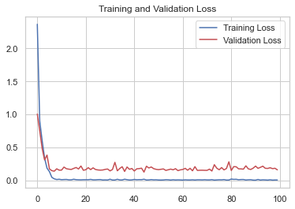

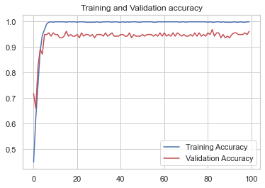

```python
visualize_loss(history.history)
visualize_acc(history.history)
```

The training of the model will be performed a second time to investigate if similar results occur or if the model is too sensitive to the size of the data

```python
history = model.fit(train_data,
                    validation_data=test_data,
                    epochs=EPOCHS,
                    batch_size=BATCH_SIZE,
                    verbose=0,
                    callbacks=[CustomCallback()])
```

```python
_, train_acc = model.evaluate(train_data, verbose=0)
_, test_acc = model.evaluate(test_data, verbose=0)
print('Training accuracy: %.3f, Testing accuracy: %.3f' % (train_acc, test_acc))
```

```
Training accuracy: 0.998, Testing accuracy: 0.949
```

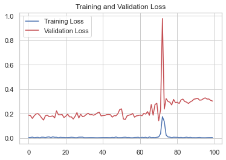

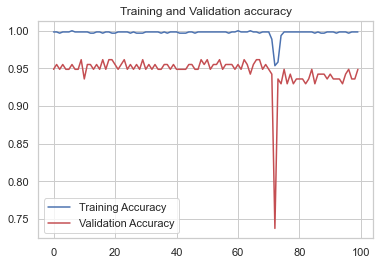

[output not shown]

```python
visualize_loss(history.history)
visualize_acc(history.history)
BEST_EPOCH = np.argmin(history.history['val_loss'])
print('The lowest Validation Loss occured in the', BEST_EPOCH, 'epoch')
```

```python
# we split the dataset
test_size = int(ds_size * 0.2)
train_data = data.skip(test_size)
test_data = data.take(test_size)
```

### K Fold Validation

```python
K = 4

num_val_samples = len(train_data) // K

all_loss = []
all_val_loss = []
all_acc = []
all_val_acc = []

for i in range(K):
    print('processing fold', i)

    # we split the dataset
    test_size = int(num_val_samples * 0.2)

    partial_train_data = train_data.skip(test_size)
    val_data = train_data.take(test_size)

    partial_train_data = configure_for_training(partial_train_data, is_train=True)
    val_data = configure_for_training(val_data, is_train=True)

    history = model.fit(partial_train_data,
                        validation_data=(val_data),
                        epochs=EPOCHS,
                        batch_size=BATCH_SIZE,
                        verbose=0)

    #evaluate the model on the validation data
    _, train_acc = model.evaluate(partial_train_data, verbose=0)
    _, test_acc = model.evaluate(val_data, verbose=0)

    loss_history = history.history['loss']
    val_loss_history = history.history['val_loss']
    acc_history = history.history['acc']
    val_acc_history = history.history['val_acc']

    all_loss.append(loss_history)
    all_val_loss.append(val_loss_history)
    all_acc.append(acc_history)
    all_val_acc.append(val_acc_history)
```

```
processing fold 0
processing fold 1
processing fold 2
processing fold 3
```

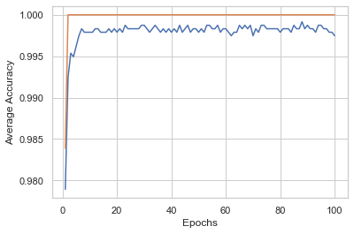

```python
average_loss_history = [np.mean([x[i] for x in all_loss])for i in range(EPOCHS)]
average_val_loss_history = [np.mean([x[i] for x in all_val_loss])for i in range(EPOCHS)]
average_acc_history = [np.mean([x[i] for x in all_acc])for i in range(EPOCHS)]
average_val_acc_history = [np.mean([x[i] for x in all_val_acc])for i in range(EPOCHS)]


plt.plot(range(1, len(average_acc_history) + 1), average_acc_history)
plt.plot(range(1, len(average_val_acc_history) + 1), average_val_acc_history)
plt.xlabel('Epochs')
plt.ylabel('Average Accuracy')

plt.show()
```

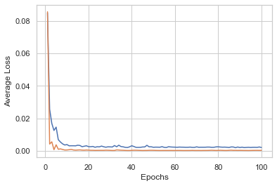

```python
plt.plot(range(1, len(average_loss_history) + 1), average_loss_history)
plt.plot(range(1, len(average_val_loss_history) + 1), average_val_loss_history)
plt.xlabel('Epochs')
plt.ylabel('Average Loss')

plt.show()
```

### Building the Final Model

```python
EPOCHS = 6
# we split the dataset
test_size = int(ds_size * 0.2)
train_data = data.skip(test_size)
test_data = data.take(test_size)

train_data = configure_for_training(train_data, is_train=True)
test_data = configure_for_training(test_data, is_train=True)
```

```python
model.compile(optimizer='adam',
              loss='sparse_categorical_crossentropy',
              metrics=['acc'])
model.fit(train_data,
          epochs=EPOCHS,
          batch_size=BATCH_SIZE,
          verbose=0,
          callbacks=[CustomCallback()])
```

```
<keras.callbacks.History at 0x2a0e700e280>
```

```python
_, test_acc = model.evaluate(test_data, verbose=0)
```

```python
print('The final training outcome', test_acc)
```

```
The final training outcome 0.9935897588729858
```

# Results

The evaluation of the final model on the test data returned an accuracy of nearly 100%. This indicates that there is a problem with the model. There are two likely culprits:

- unbalanced dataset that does not accurately describe the problem
- data leakage in the learning model

The first problem leads to a representation issue as all classes are not equally in the validation/training set. This in turn has the data over fit to one class over another. It also impacts optimization as the learning model never gets a good look at the underlying classes. The second problem causes the model to learn the wrong patterns allowing it to model the training set well, but fail on unseen data.

As the data set is small, but has 3 class labels, an unbalanced dataset is the most likely scenario for causing this unusual model result. To confirm this in the following cell the counts of the class distribution will be displayed.

```python
for i in range(num_classes):
    count = 0
    _dir = os.listdir(data_dir +"\\"+classes[i])
    for root, dirs, files in os.walk(data_dir):
        for file in files:
            if file.endswith(').png'):
                if file.startswith(classes[i]):
                    count += 1
    print('\n',"There are",count,"data points available in class:", classes[i],'\n')
```

```
 There are 437 data points available in class: benign


 There are 210 data points available in class: malignant


 There are 133 data points available in class: normal
```

From the displayed distribution of data points it can be seen that the dataset is unbalanced towards the benign class. In order to fix the model in the future, there are 4 potential approaches:

- Get a larger dataset
- Undersampling: Randomly delete the class which has significant observations[2]
- Oversampling: Increase the number of observations (make copies of existing samples)[2]
- Synthetic Sampling: manufacture observations by sampling nearest neighbours[2]

As larger datasets are often not available, the 3 other solutions must strongly be considered. With this particular dataset, deleting the benign class would remove important data from the classification process. This makes undersampling a poor choice for this problem. Synthetic Sampling also quickly becomes a poor choice as this dataset is composed of images which processing/sampling is computationally expensive. Furthermore, the order the images appear in the dataset does describe the dataset. This leaves Oversampling as the best solution, The drawback being that it may cause overfitting in the model.

# Conclusion

Despite the fact that the produced learning model ultimately failed in the goal of correctly identifying breast cancer lesions. It showed that there is significant potential for using deep learning models in Identifying cancers. That is if a significantly large enough and balanced dataset can be acquired, or the correct preprocessing of the data to produce a more balanced model is performed.

# Refrences

- [1] Al-Dhabyani W, Gomaa M, Khaled H, Fahmy A. Dataset of breast ultrasound images. Data in Brief. 2020 Feb;28:104863. DOI: 10.1016/j.dib.2019.104863. Accessed 20 Aug 2022.
  - https://www.kaggle.com/datasets/aryashah2k/breast-ultrasound-images-dataset
- [2] Chatterjee, Shubrashankh. “Deep learning unbalanced training data?Solve it like this.” Towards Data Science, Accessed 20 Aug 2022.
  - https://towardsdatascience.com/deep-learning-unbalanced-training-data-solve-it-like-this-6c528e9efea6.
- [3] Karakaya, Murat. “tf.data: Build Efficient TensorFlow Input Pipelines for Image Datasets.” Medium, 20 February 2021, Accessed 20 Aug 2022.
  - https://medium.com/deep-learning-with-keras/tf-data-build-efficient-tensorflow-input-pipelines-for-image-datasets-47010d2e4330.
- [4] cm3015 Machine Learning and Neural Networks, authors: Tim Blackwell, Jamie Ward
  - https://www.coursera.org/learn/uol-cm3015-machine-learning-and-neural-networks/home/week/1